# Estudio sobre infectados de coronavirus

Ricardo Alberich, Juan Gabriel Gomila y Arnau Mir

# Planteamiento y modelado del problema

## Introducción

En estos días está como noticia estrella la pandemía por **coronavirus** que estamos sufriendo prácticamente todos los humanos que habitan nuestro planeta.

Una de las cuestiones más planteadas es cómo irán evolucionando los infectados, es decir, si a partir de los datos que se tienen, podemos predecir si habrá un rebrote o no.

La respuesta a esta última pregunta hace que los políticos tomen medidas de confinamiento para evitar el posible rebrote.

En esta presentación, a partir de uno de los **modelos matemáticos** para predecir el comportamiento de **epidemias**, vamos a estudiar cómo habría **evolucionado** la epidemia en diferentes países.

## El modelo SIR

El modelo SIR (**S** de susceptibles de contraer la enfermedad, **I** de infectados y **R** de recuperados), define en un tiempo fijado $t$, las variables siguientes:

- $S(t)$ número de susceptibles de contraer la enfermedad.
- $I(t)$ número de infectados.
- $R(t)$ número de recuperados.

El modelo **SIR** de define los parámetros siguientes:

- $\beta$: el número medio de contactos por unidad de tiempo.
- $\gamma$: el número de recuperados por unidad de tiempo dividido por el total de infectados.

## El modelo SIR

De esta manera, la tasa de transición entre los infectados y los susceptibles será: $\beta\cdot \frac{I(t)}{N}$, es decir, el número medio de contactos por unidad de tiempo por la probabilidad de ser infectado.

La tasa de transición entre los infectados y los recuperados será simplemente, $\gamma$.

## El modelo SIR

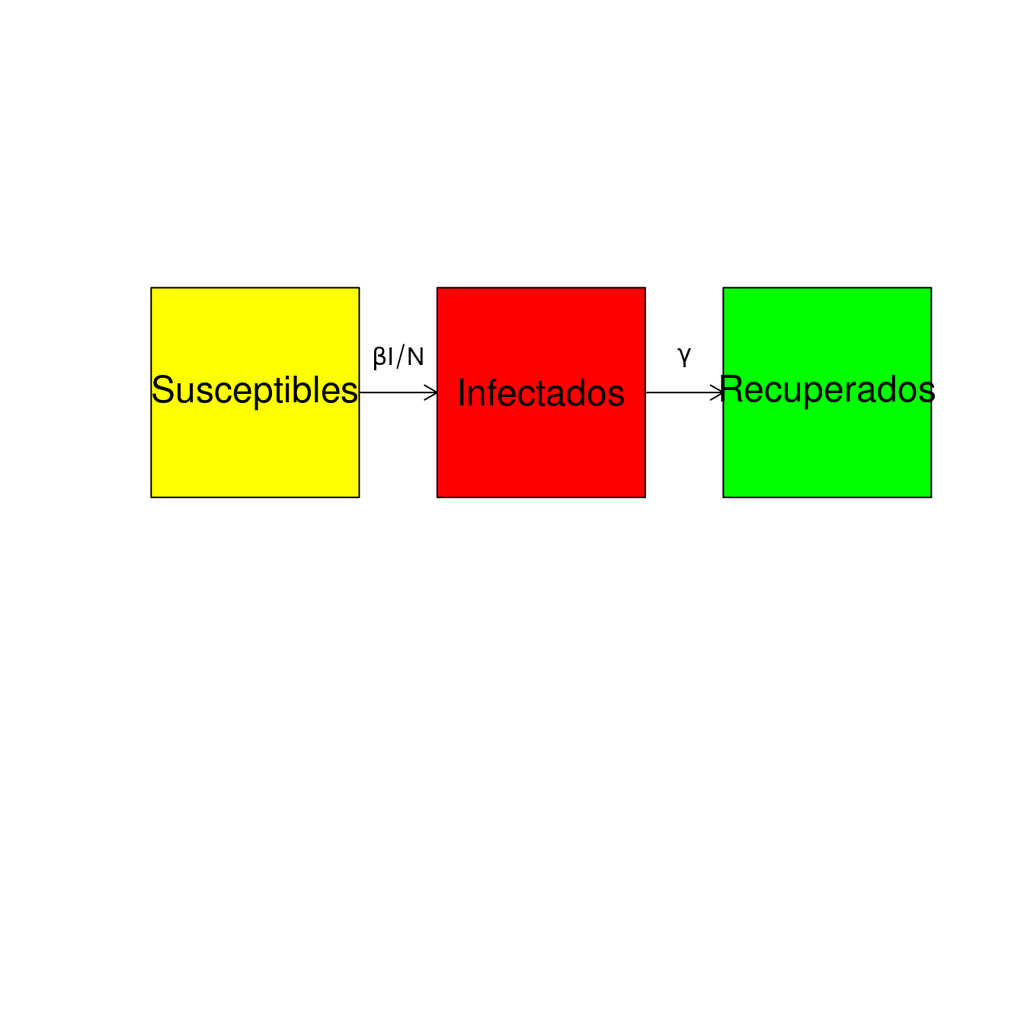

## El modelo SIR

Las ecuaciones diferenciales del modelo son las siguientes:
$$\begin{array}{rl}
\frac{dS}{dt} & = -\frac{\beta I}{N}\cdot S,\\
\frac{dI}{dt} & = \frac{\beta I}{N}\cdot S-\gamma I,\\
\frac{dR}{dt} & = \gamma I
\end{array}$$

## El modelo SIR

Es decir,

- la variación de susceptibles por unidad de tiempo sería la tasa de transición desde susceptibles hacia infectados por el número total de susceptibles con un signo menos indicando que los susceptibles disminuirán si la tasa hacia infectados aumenta,
- la variación de infectados por unidad de tiempo sería la tasa de transición desde susceptibles hacia infectados por el número total de susceptibles restándole la variación de recuperados que será la tasa de transición desde infectados a recuperados por el número total de infectados y,
- la variación de recuperados por unidad de tiempo sería simplemente la tasa de transición desde infectados a recuperados por el número total de infectados.

## El modelo SIR

El sistema diferencial anterior es no lineal. Sin embargo, se puede verificar que $S(t)+I(t)+R(t)=N$, donde $N$ es la población total ya que $\frac{dS}{dt}+\frac{dI}{dt}+\frac{dR}{dt}=0$.

Por tanto, la funció $R(t)$ de recuperados puede escribirse en función de las otras dos funciones $R(t)=N-S(t)-I(t)$ y el sistema diferencial anterior puede considerarse un sistema de 2 ecuaciones ya que la tercera función $R(t)$ puede escribirse en función de las otras dos.

## El modelo SIR

Además, la solución $S(t)$ puede obtenerse dividiendo la primera entre la última ecuación y integrando separando las variable $S$ y $R$:
$$S(t)=S(0)\cdot \mathrm{e}^{-\frac{\beta}{\gamma}(R(t)-R(0))/N}.$$
Al valor $\frac{\beta}{\gamma}$ se le llama **número básico de reproducción** y se denota por $R_0$.

## El modelo SIR

Este número juega un papel clave para estudiar la evolución de los infectados ya que:
$$\frac{dI}{dt} = \frac{\beta I}{N}\cdot S-\gamma I =\left(R_0\frac{S}{N}-1\right)\cdot\gamma I.$$
Entonces:

- si $R_0\frac{S}{N}-1 >0$ o si $R_0 >\frac{N}{S}$, significa que $\frac{dI}{dt}>0$ y la función $I(t)$ crecerá aumentando el número de infectados.

## El modelo SIR

Como conocemos la expresión de $S(t)$, la condición anterior será:
$$R_0 > \frac{N}{S(t)}=\frac{N}{S(0)}\cdot\mathrm{e}^{R_0\cdot (R(t)-R(0))/N}.$$
La condición anterior es la que nos dirá si los infectados van a aumentar o por el contrario disminuir.

Los valores de $S(0)$ y $R(0)$ son, respectivamente, $S(0)=N$ y $R(0)=0$ ya que en el momento inicial todos los individuos son susceptibles y no hay ningún individuo recuperado.

## El modelo SIR

Es decir,

- si $R_0 > \mathrm{e}^{\frac{R_0\cdot R(t)}{N}}$ en el momento $t$, la epidemia tenderá a aumentar y se tendrán que tomar medidas y
- si $R_0 < \mathrm{e}^{\frac{R_0\cdot R(t)}{N}}$ en el momento $t$, la epidemia tenderá a disminuir.

## Estimación de $R_0$

Para estimar el valor de $R_0$, tenemos que pensar que dispondremos de una tabla de datos que para unos ciertos tiempos $t_1,\ldots, t_n$, nos darán $S(t_i),I(t_i)$ y $R(t_i)$.

Para estimar el valor de $R_0$ veamos en primer lugar cómo aparece en la expresión de $S(t)$:
$$\begin{array}{rl}
S(t) & = N\cdot \mathrm{e}^{-R_0\cdot \frac{R(t)}{N}}, \\
\ln\left(\frac{S(t)}{N}\right) & = -R_0 \cdot \frac{R(t)}{N},\\
N\ln S(t) & = N\ln N-R_0 \cdot R(t).
\end{array}$$

## Estimación de $R_0$

Vemos que hay una **relación lineal** entre las variables $Y=N\ln S(t)$ y $X=R(t)$. Si hacemos la recta de regresión de la variable $Y_i=N\ln S(t_i)$, $i=1,\ldots,n$ en función de la variable $X_i=R(t_i)$, el valor de $R_0$ será la pendiente cambiada de signo de dicha recta.

Una vez hallado el valor de $R_0$ a partir de dicha recta de regresión y observando el valor del coeficiente de determinación $R^2$ para testear la calidad de la regresión, podemos comparar el valor de la estimación de $R_0$ con $\mathrm{e}^{\frac{R_0\cdot R(t)}{N}}$ para un $t$ determinado para ver si la infección se expandirá o disminuirá.

## Estudio en R

```r
covid19=read.csv("covid_19_clean_complete.csv")
covid19$Date %<>% ymd()
str(covid19)
```

```
## 'data.frame':    49068 obs. of  10 variables:
##  $ Province.State: chr  "" "" "" "" ...
##  $ Country.Region: chr  "Afghanistan" "Albania" "Algeria" "Andorra" ...
##  $ Lat           : num  33.9 41.2 28 42.5 -11.2 ...
##  $ Long          : num  67.71 20.17 1.66 1.52 17.87 ...
##  $ Date          : Date, format: "2020-01-22" "2020-01-22" ...
##  $ Confirmed     : int  0 0 0 0 0 0 0 0 0 0 ...
##  $ Deaths        : int  0 0 0 0 0 0 0 0 0 0 ...
##  $ Recovered     : int  0 0 0 0 0 0 0 0 0 0 ...
##  $ Active        : int  0 0 0 0 0 0 0 0 0 0 ...
##  $ WHO.Region    : chr  "Eastern Mediterranean" "Europe" "Africa" "Europe" ...
```

## Número de habitantes por países

```r
library(wbstats)
pop_data <- wb(indicator = "SP.POP.TOTL", startdate = 2018, enddate = 2019)
```

## Número de habitantes por países

```r
pop_data[pop_data$country=="Spain",]
```

```
##     iso3c date    value indicatorID         indicator iso2c country
## 453   ESP 2019 47076781 SP.POP.TOTL Population, total    ES   Spain
## 454   ESP 2018 46797754 SP.POP.TOTL Population, total    ES   Spain
```

```r
pop_data[pop_data$country=="Italy",]
```

```
##     iso3c date    value indicatorID         indicator iso2c country
## 287   ITA 2019 60297396 SP.POP.TOTL Population, total    IT   Italy
## 288   ITA 2018 60421760 SP.POP.TOTL Population, total    IT   Italy
```

```r
pop_data[pop_data$country=="Chile",]
```

```
##     iso3c date    value indicatorID         indicator iso2c country
## 175   CHL 2019 18952038 SP.POP.TOTL Population, total    CL   Chile
## 176   CHL 2018 18729160 SP.POP.TOTL Population, total    CL   Chile
```

```r
covid19.chile = covid19[covid19$Country.Region=="Chile",]
length(covid19.chile$Confirmed)
```

```
## [1] 188
```

```r
length(covid19.chile$Date)
```

```
## [1] 188
```

```r
class(covid19.chile)
```

```
## [1] "data.frame"
```

```r
infectados.por.dia<-aggregate(covid19.chile$Confirmed ~ covid19.chile$Date, FUN = sum)
fallecidos.por.dia = aggregate(covid19.chile$Deaths ~ covid19.chile$Date,FUN=sum)
infectados.por.dia2 = infectados.por.dia[,2] + fallecidos.por.dia[,2]
recuperados.por.dia = aggregate(covid19.chile$Recovered ~ covid19.chile$Date,FUN=sum)
```

## Estudio para Chile

Los susceptibles $S(t)$ se calculan como $S(t)=N-I(t)-R(t)$:

```r
habitantes=pop_data$value[pop_data$country=="Chile"]
susceptibles.por.dia = habitantes-infectados.por.dia2-recuperados.por.dia[,2]
```

```r
tabla.chile = data.frame(unique(covid19.chile$Date),susceptibles.por.dia,
                          infectados.por.dia2,recuperados.por.dia[,2])
names(tabla.chile) = c("Fecha", "Susceptibles","Infectados", "Recuperados")
```

```r
x=tabla.chile$Recuperados
y=habitantes*log(tabla.chile$Susceptibles)
summary(lm( y ~ x))
```

```
##
## Call:
## lm(formula = y ~ x)
##
## Residuals:
##      Min       1Q   Median       3Q      Max
## -2048817 -1976540    -9279  1979791  2027629
##
## Coefficients:
##               Estimate Std. Error  t value Pr(>|t|)
## (Intercept)  3.156e+08  1.737e+05 1817.267   <2e-16 ***
## x           -2.304e+00  1.351e+00   -1.706   0.0897 .
## ---
## Signif. codes:  0 '***' 0.001 '**' 0.01 '*' 0.05 '.' 0.1 ' ' 1
##
## Residual standard error: 1989000 on 186 degrees of freedom
## Multiple R-squared:  0.0154, Adjusted R-squared:  0.01011
## F-statistic:  2.91 on 1 and 186 DF,  p-value: 0.08971
```

```r
x=tabla.chile$Recuperados
y=habitantes*log(tabla.chile$Susceptibles)
summary(lm( y ~ x))
```

```
##
## Call:
## lm(formula = y ~ x)
##
## Residuals:
##      Min       1Q   Median       3Q      Max
## -2048817 -1976540    -9279  1979791  2027629
##
## Coefficients:
##               Estimate Std. Error  t value Pr(>|t|)
## (Intercept)  3.156e+08  1.737e+05 1817.267   <2e-16 ***
## x           -2.304e+00  1.351e+00   -1.706   0.0897 .
## ---
## Signif. codes:  0 '***' 0.001 '**' 0.01 '*' 0.05 '.' 0.1 ' ' 1
##
## Residual standard error: 1989000 on 186 degrees of freedom
## Multiple R-squared:  0.0154, Adjusted R-squared:  0.01011
## F-statistic:  2.91 on 1 and 186 DF,  p-value: 0.08971
```

```r
(estimación.R0 = -summary(lm(y~x))$coefficients[2])
```

```
## [1] 2.304079
```

Para ver si la epidemia se expandirá o no, hemos de comparar el valor anterior con: $\mathrm{e}^{R_0\cdot\frac{R(t)}{N}}$:

```r
dia.último = length(tabla.chile[,1])
exp(estimación.R0*tabla.chile$Recuperados[dia.último]/habitantes)
```

```
## [1] 1.039665 1.040146
```